# Heeren_NUC203_HW3-Copy1

## Homework 3

##### Big Data, Elizabeth (Libby) Heeren

1. Import the Auto MPG dataset using pandas.read_csv(), use the attribute names as explained in the dataset description as the column names (5pt), view the strings ‘?’ as the missing value, and whitespace (i.e., ‘\s+’) as the column delimiter. Print out the shape and first 5 rows of the DataFrame. (5pt)

```python
import pandas as pd
import numpy as np

auto = pd.read_csv('http://archive.ics.uci.edu/ml/machine-learning-databases/auto-mpg/auto-mpg.data'
,names = ['mpg', 'cylinders', 'displacement', 'horsepower','weight', 'acceleration', 'model_year',
          'origin', 'car_name'],
          na_values = ['?'],
          sep='\s+')

auto.head(5)
```

|  | mpg | cylinders | displacement | horsepower | weight | acceleration | model_year | origin | car_name |
| --- | --- | --- | --- | --- | --- | --- | --- | --- | --- |
| 0 | 18.0 | 8 | 307.0 | 130.0 | 3504.0 | 12.0 | 70 | 1 | chevrolet chevelle malibu |
| 1 | 15.0 | 8 | 350.0 | 165.0 | 3693.0 | 11.5 | 70 | 1 | buick skylark 320 |
| 2 | 18.0 | 8 | 318.0 | 150.0 | 3436.0 | 11.0 | 70 | 1 | plymouth satellite |
| 3 | 16.0 | 8 | 304.0 | 150.0 | 3433.0 | 12.0 | 70 | 1 | amc rebel sst |
| 4 | 17.0 | 8 | 302.0 | 140.0 | 3449.0 | 10.5 | 70 | 1 | ford torino |

```python
print("Dimensions: ", auto.shape)
```

```
Dimensions:  (398, 9)
```

1. Delete the “car_name” column using .drop() and drop the rows containing NULL value using .dropna(). Print out the shape and first 5 rows of the DataFrame. (5pt)

```python
auto = auto.drop(columns=['car_name'])
```

```python
auto_clean = auto.dropna()
```

```python
auto_clean.head(5)
```

|  | mpg | cylinders | displacement | horsepower | weight | acceleration | model_year | origin |
| --- | --- | --- | --- | --- | --- | --- | --- | --- |
| 0 | 18.0 | 8 | 307.0 | 130.0 | 3504.0 | 12.0 | 70 | 1 |
| 1 | 15.0 | 8 | 350.0 | 165.0 | 3693.0 | 11.5 | 70 | 1 |
| 2 | 18.0 | 8 | 318.0 | 150.0 | 3436.0 | 11.0 | 70 | 1 |
| 3 | 16.0 | 8 | 304.0 | 150.0 | 3433.0 | 12.0 | 70 | 1 |
| 4 | 17.0 | 8 | 302.0 | 140.0 | 3449.0 | 10.5 | 70 | 1 |

```python
print("New Dimensions: ", auto_clean.shape)
```

```
New Dimensions:  (392, 8)
```

1. For the ‘origin’ column with categorical attribute, replace it with the columns with numerical attributes using one-hot encoding. Print out the shape and first 5 rows of the DataFrame. (5pt)

```python
origindummies = pd.get_dummies(auto_clean['origin'], prefix="origin")
auto_clean = pd.concat([auto_clean.drop(columns='origin'), origindummies], axis=1)
```

```python
auto_clean.head(5)
```

|  | mpg | cylinders | displacement | horsepower | weight | acceleration | model_year | origin_1 | origin_2 | origin_3 |
| --- | --- | --- | --- | --- | --- | --- | --- | --- | --- | --- |
| 0 | 18.0 | 8 | 307.0 | 130.0 | 3504.0 | 12.0 | 70 | 1 | 0 | 0 |
| 1 | 15.0 | 8 | 350.0 | 165.0 | 3693.0 | 11.5 | 70 | 1 | 0 | 0 |
| 2 | 18.0 | 8 | 318.0 | 150.0 | 3436.0 | 11.0 | 70 | 1 | 0 | 0 |
| 3 | 16.0 | 8 | 304.0 | 150.0 | 3433.0 | 12.0 | 70 | 1 | 0 | 0 |
| 4 | 17.0 | 8 | 302.0 | 140.0 | 3449.0 | 10.5 | 70 | 1 | 0 | 0 |

```python
print("New Dimensions: ", auto_clean.shape)
```

```
New Dimensions:  (392, 10)
```

1. Separate the “mpg” column from other columns and view it as the label vector and others as the feature matrix. Split the data into a training set (80%) and testing set (20%) using train_test_split and print out their shapes. Describe the statistics of your training dataset by using .describe(). (5pt)

```python
X_auto = auto_clean.drop('mpg', axis=1)
y_auto = auto_clean['mpg']

print("Feature Matrix: ", X_auto.shape)
print("Target: ", y_auto.shape)
```

```
Feature Matrix:  (392, 9)
Target:  (392,)
```

```python
from sklearn.model_selection import train_test_split

Xtrain, Xtest, ytrain, ytest = train_test_split(X_auto, y_auto,
                                                test_size = 0.2,
                                                random_state=0)
print("Xtrain: ", Xtrain.shape)
print("ytrain: ", ytrain.shape)
print()
print("Xtest: ", Xtest.shape)
print("ytest: ", ytest.shape)
```

```
Xtrain:  (313, 9)
ytrain:  (313,)

Xtest:  (79, 9)
ytest:  (79,)
```

```python
Xtrain.describe()
```

|  | cylinders | displacement | horsepower | weight | acceleration | model_year | origin_1 | origin_2 | origin_3 |
| --- | --- | --- | --- | --- | --- | --- | --- | --- | --- |
| count | 313.000000 | 313.000000 | 313.000000 | 313.000000 | 313.000000 | 313.000000 | 313.000000 | 313.000000 | 313.000000 |
| mean | 5.447284 | 192.787540 | 104.009585 | 2972.255591 | 15.560383 | 76.070288 | 0.623003 | 0.169329 | 0.207668 |
| std | 1.690263 | 103.201153 | 37.915348 | 841.134947 | 2.785476 | 3.660449 | 0.485410 | 0.375643 | 0.406287 |
| min | 3.000000 | 68.000000 | 46.000000 | 1613.000000 | 8.000000 | 70.000000 | 0.000000 | 0.000000 | 0.000000 |
| 25% | 4.000000 | 105.000000 | 78.000000 | 2230.000000 | 13.600000 | 73.000000 | 0.000000 | 0.000000 | 0.000000 |
| 50% | 4.000000 | 151.000000 | 95.000000 | 2815.000000 | 15.500000 | 76.000000 | 1.000000 | 0.000000 | 0.000000 |
| 75% | 8.000000 | 260.000000 | 120.000000 | 3574.000000 | 17.000000 | 79.000000 | 1.000000 | 0.000000 | 0.000000 |
| max | 8.000000 | 455.000000 | 230.000000 | 5140.000000 | 24.800000 | 82.000000 | 1.000000 | 1.000000 | 1.000000 |

1. Check statistics of each feature column and normalize the feature columns so that their mean is zero and variance is one. Describe the statistics of your normalized training dataset by using .describe(). (5pt)

```python
mean = Xtrain.mean(axis=0)
Xtrain -= mean
std = Xtrain.std(axis=0)
Xtrain /= std

Xtest -= mean
Xtest /= std
```

```python
Xtrain.describe() # all variables now have mean of 0 and std of 1
```

|  | cylinders | displacement | horsepower | weight | acceleration | model_year | origin_1 | origin_2 | origin_3 |
| --- | --- | --- | --- | --- | --- | --- | --- | --- | --- |
| count | 3.130000e+02 | 3.130000e+02 | 3.130000e+02 | 3.130000e+02 | 3.130000e+02 | 3.130000e+02 | 3.130000e+02 | 3.130000e+02 | 3.130000e+02 |
| mean | -1.383345e-17 | 1.569564e-17 | -1.166089e-16 | -2.430608e-16 | 4.717561e-15 | -3.114300e-16 | 1.156335e-16 | -1.166976e-16 | -1.816084e-16 |
| std | 1.000000e+00 | 1.000000e+00 | 1.000000e+00 | 1.000000e+00 | 1.000000e+00 | 1.000000e+00 | 1.000000e+00 | 1.000000e+00 | 1.000000e+00 |
| min | -1.447872e+00 | -1.209168e+00 | -1.529976e+00 | -1.615978e+00 | -2.714216e+00 | -1.658345e+00 | -1.283457e+00 | -4.507714e-01 | -5.111354e-01 |
| 25% | -8.562482e-01 | -8.506450e-01 | -6.859909e-01 | -8.824453e-01 | -7.037877e-01 | -8.387734e-01 | -1.283457e+00 | -4.507714e-01 | -5.111354e-01 |
| 50% | -8.562482e-01 | -4.049135e-01 | -2.376237e-01 | -1.869564e-01 | -2.167795e-02 | -1.920189e-02 | 7.766562e-01 | -4.507714e-01 | -5.111354e-01 |
| 75% | 1.510248e+00 | 6.512763e-01 | 4.217399e-01 | 7.153958e-01 | 5.168297e-01 | 8.003696e-01 | 7.766562e-01 | -4.507714e-01 | -5.111354e-01 |
| max | 1.510248e+00 | 2.540790e+00 | 3.322940e+00 | 2.577166e+00 | 3.317070e+00 | 1.619941e+00 | 7.766562e-01 | 2.211332e+00 | 1.950178e+00 |

1. Build a Sequential NN model in Keras with two densely connected hidden layers (32 neurons and ReLU activation function for each hidden layer), and an output layer that returns a single, continuous value. Print out the model summary using .summary(). (10pt)

```python
from numpy.random import seed
import tensorflow as tf
from tensorflow import keras

# Set seed for experiment reproducibility
seed = 0
tf.random.set_seed(seed)
np.random.seed(seed)
```

```python
from tensorflow.keras import models
from tensorflow.keras import layers

tf.random.set_seed(seed)
np.random.seed(seed)

model = models.Sequential()
model.add(layers.Dense(32, activation='relu', input_shape=(Xtrain.shape[1],)))
model.add(layers.Dense(32, activation='relu'))
model.add(layers.Dense(1))

model.summary()
```

```
Model: "sequential_3"
_________________________________________________________________
Layer (type)                 Output Shape              Param #
=================================================================
dense_9 (Dense)              (None, 32)                320
_________________________________________________________________
dense_10 (Dense)             (None, 32)                1056
_________________________________________________________________
dense_11 (Dense)             (None, 1)                 33
=================================================================
Total params: 1,409
Trainable params: 1,409
Non-trainable params: 0
_________________________________________________________________
```

1. Define the appropriate loss function, optimizer, and metrics for this specific problem and compile the NN model. (10pt)

```python
tf.random.set_seed(seed)
np.random.seed(seed)

model.compile(optimizer='rmsprop', loss='mse', metrics=['mae'])
```

1. Put aside 20% of the training data as the validation dataset by setting validation_split = 0.2 and set verbose = 0 to compress the model training status in Keras .fit(). Train the NN model for 500 epochs and batch size of 32 and plot the training and validation loss progresses with respect to the epoch number. (10pt)

```python
tf.random.set_seed(seed)
np.random.seed(seed)

m = model.fit(Xtrain, ytrain,
          validation_split = 0.2,
          epochs=500,
          batch_size=32,
          verbose=0)
```

```python
m.history.keys()
```

```
dict_keys(['loss', 'mae', 'val_loss', 'val_mae'])
```

```python
loss = m.history['loss']
val_loss = m.history['val_loss']
```

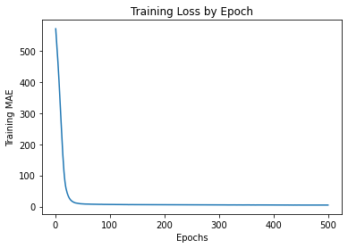

```python
import matplotlib.pyplot as plt

plt.plot(range(1, len(loss) + 1), loss)
plt.xlabel('Epochs')
plt.ylabel('Training MAE')
plt.title('Training Loss by Epoch')
plt.show()
```

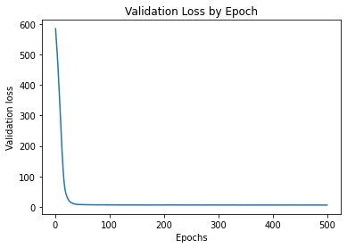

```python
import matplotlib.pyplot as plt

plt.plot(range(1, len(val_loss) + 1), val_loss)
plt.xlabel('Epochs')
plt.ylabel('Validation loss')
plt.title('Validation Loss by Epoch')
plt.show()
```

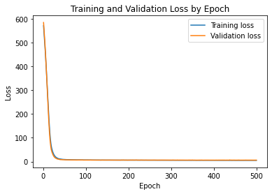

```python
# Plotting them together on one graph

# line 1 points
x1 = range(1, 501)
y1 = loss
# plotting the line 1 points
plt.plot(x1, y1, label = "Training loss")
# line 2 points
x2 = range(1, 501)
y2 = val_loss
# plotting the line 2 points
plt.plot(x2, y2, label = "Validation loss")
plt.xlabel('Epoch')
# Set the y axis label of the current axis.
plt.ylabel('Loss')
# Set a title of the current axes.
plt.title('Training and Validation Loss by Epoch')
# show a legend on the plot
plt.legend()
# Display a figure.
plt.show()
```

1. Use the trained NN model to make predictions on the testing dataset and observe the prediction error. (5pt)

```python
test_mse_score, test_mae_score = model.evaluate(Xtest, ytest)
```

```python
test_mae_score
```

```
1.6870677471160889
```